# Anova_part2

Nadezhda Tsurikova

2023-01-25

```r
library(dplyr)
library(readxl)
library(tidyverse)
library(tidyr)
library(tibble)
soccer_general <- read_excel("soccer.xlsx")[, 2:6] %>% mutate(Position = as.factor(Position),
    Nationality = as.factor(Nationality),
    Age = as.numeric(Age),
    Height = as.numeric(Height)
) %>%
filter(Nationality %in% c("Spanish", "Italian", "German", "English", "Argentinian"))

soccer_wrk <- soccer_general[sample(1:nrow(soccer_general), 150), ] %>%
    mutate(Nationality = factor(Nationality))
```

```r
library(sandwich)
library(lmtest)
lm(Height~Position, data=soccer_wrk) %>% anova
```

```
## Analysis of Variance Table
##
## Response: Height
##            Df Sum Sq Mean Sq F value    Pr(>F)
## Position    3 2078.2  692.72  20.979 2.339e-11 ***
## Residuals 146 4820.9   33.02
## ---
## Signif. codes:  0 '***' 0.001 '**' 0.01 '*' 0.05 '.' 0.1 ' ' 1
```

При уровне значимости альфа =0.05(5%) мы можем отвергнуть нулевую гипотезу об одновременном равенстве среднего роста для игроков на разных позициях на поле, т.е. можно считать, что рост игрока связан с его позицией на поле.

```r
oneway.test(Height ~ Position, soccer_wrk)
```

```
##
##  One-way analysis of means (not assuming equal variances)
##
## data:  Height and Position
## F = 36.763, num df = 3.000, denom df = 68.933, p-value = 2.642e-14
```

с помощью F-теста Уэлша получаем такой же результат, если сделать предположение, что дисперсия в росте может быть разной в зависимости от позиции игрока на поле (т.е. отвергаем нулевую гипотезу и можем считать, что рост игрока связан с его позицией на поле)

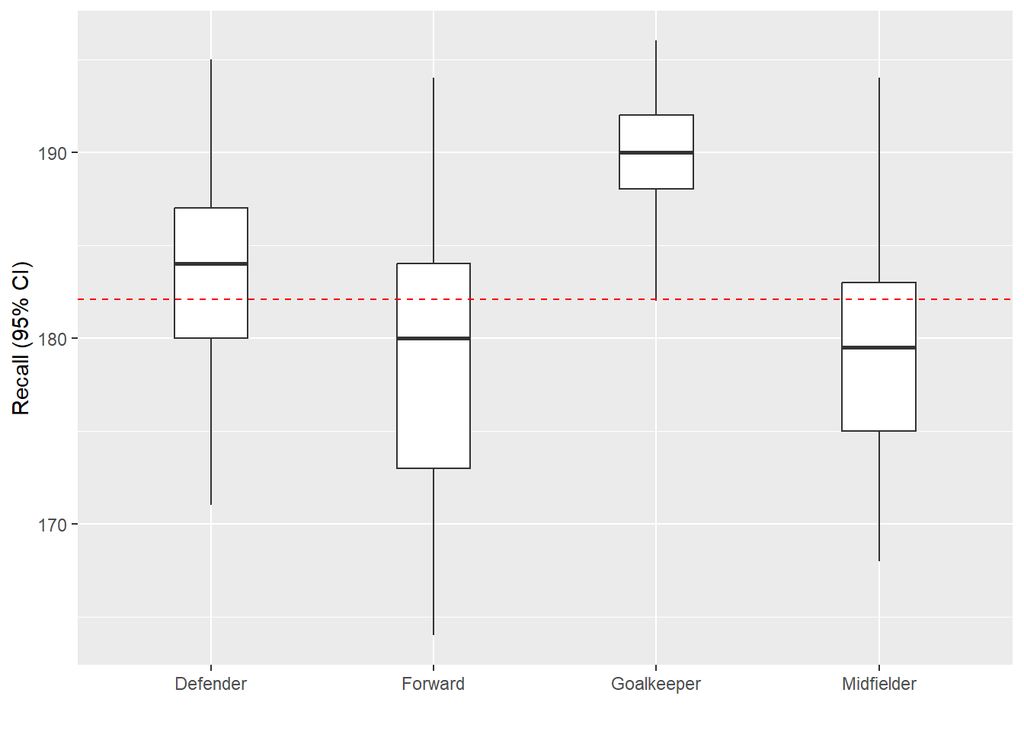

```r
soccer_wrk %>%
 ggplot(aes(Position, Height)) +
  geom_boxplot(width=.33) +
  geom_hline(yintercept = mean(soccer_wrk$Height), color = "red", linetype = "dashed", size = 0.5) +
  ylab("Recall (95% CI)") +
  xlab("")
```

Для наглядности нарисовали боксплоты.

Post-hoc анализ: процедура Хоторна-Бретца-Вестфалла для контроля FWER:

- скорректированные p-values:

```r
hbw <- lm(Height ~ Position, soccer_wrk) %>%
  multcomp::glht(linfct = multcomp::mcp(Position = "Tukey"))

hbw_res <- hbw %>% summary()
print(hbw_res)
```

```
##
##   Simultaneous Tests for General Linear Hypotheses
##
## Multiple Comparisons of Means: Tukey Contrasts
##
##
## Fit: lm(formula = Height ~ Position, data = soccer_wrk)
##
## Linear Hypotheses:
##                              Estimate Std. Error t value Pr(>|t|)
## Forward - Defender == 0       -4.8550     1.3744  -3.532  0.00307 **
## Goalkeeper - Defender == 0     6.3864     1.5241   4.190  < 0.001 ***
## Midfielder - Defender == 0    -3.9886     1.1576  -3.446  0.00399 **
## Goalkeeper - Forward == 0     11.2414     1.6465   6.827  < 0.001 ***
## Midfielder - Forward == 0      0.8664     1.3146   0.659  0.91094
## Midfielder - Goalkeeper == 0 -10.3750     1.4704  -7.056  < 0.001 ***
## ---
## Signif. codes:  0 '***' 0.001 '**' 0.01 '*' 0.05 '.' 0.1 ' ' 1
## (Adjusted p values reported -- single-step method)
```

```r
hbw_ci <- hbw_res %>% confint()
hbw_ci
```

```
##
##   Simultaneous Confidence Intervals
##
## Multiple Comparisons of Means: Tukey Contrasts
##
##
## Fit: lm(formula = Height ~ Position, data = soccer_wrk)
##
## Quantile = 2.5911
## 95% family-wise confidence level
##
##
## Linear Hypotheses:
##                              Estimate lwr      upr
## Forward - Defender == 0       -4.8550  -8.4163  -1.2937
## Goalkeeper - Defender == 0     6.3864   2.4373  10.3354
## Midfielder - Defender == 0    -3.9886  -6.9882  -0.9891
## Goalkeeper - Forward == 0     11.2414   6.9751  15.5077
## Midfielder - Forward == 0      0.8664  -2.5400   4.2727
## Midfielder - Goalkeeper == 0 -10.3750 -14.1849  -6.5651
```

Смотрим 95% ДИ, строим график для наглядности

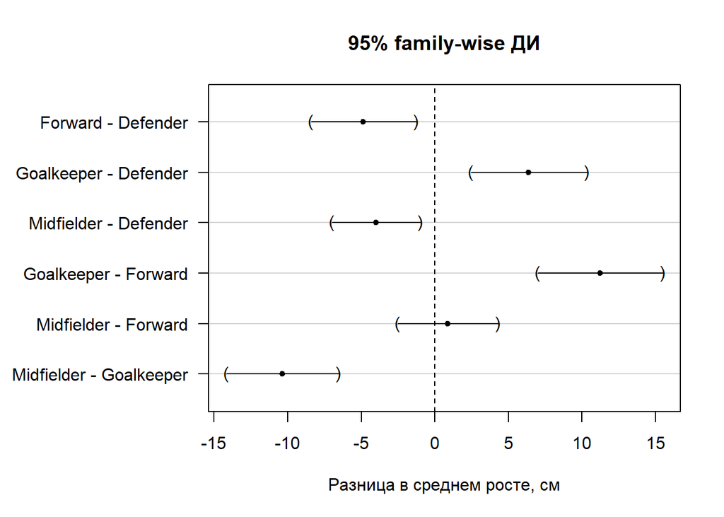

```r
plot1 <- par()$mar
par(mar = c(5, 10, 4, 2)+0.1)
hbw_res %>% plot(xlab = "Разница в среднем росте, см", main = "95% family-wise ДИ")
```

```r
par(mar = plot1)
```

Проведем попарные тесты:

```r
soccer_wrk %>%  pull(Height) %>% mean(na.rm = TRUE)
```

```
## [1] 182.08
```

Проводим попарное сравнение

```r
library(car)
position.lm <- lm(Height ~ Position,
                    data=soccer_wrk)
position.anova <- car::Anova(position.lm, type=3)
position.anova
```

```
## Anova Table (Type III tests)
##
## Response: Height
##              Sum Sq  Df   F value    Pr(>F)
## (Intercept) 1483415   1 44925.222 < 2.2e-16 ***
## Position       2078   3    20.979 2.339e-11 ***
## Residuals      4821 146
## ---
## Signif. codes:  0 '***' 0.001 '**' 0.01 '*' 0.05 '.' 0.1 ' ' 1
```

```r
position.lsm <- emmeans::emmeans(position.lm, pairwise~Position, adjust="fdr")
position.contrasts <- emmeans::contrast(position.lsm, "eff")
```

```
## I bet you wanted to call this with just object[[1]] - use '[[]]' or which' if I'm wrong.
## See '? emm_list' for more information
```

```r
position.contrasts
```

```
##  contrast          estimate    SE  df t.ratio p.value
##  Defender effect      0.614 0.793 146   0.775  0.4396
##  Forward effect      -4.241 0.907 146  -4.676  <.0001
##  Goalkeeper effect    7.001 1.019 146   6.867  <.0001
##  Midfielder effect   -3.374 0.740 146  -4.558  <.0001
##
## P value adjustment: fdr method for 4 tests
```

Сравниваем попарно 95% ДИ для разницы средних в росте каждой из позиции на поле

```r
library(lsmeans)
position.model <- lm(Height ~ Position,
                    data=soccer_wrk)
position.lsm <- lsmeans::lsmeans(position.model, pairwise~Position)
position.lsm
```

```
## $lsmeans
##  Position   lsmean    SE  df lower.CL upper.CL
##  Defender      184 0.866 146      182      185
##  Forward       179 1.067 146      177      181
##  Goalkeeper    190 1.254 146      188      192
##  Midfielder    180 0.768 146      178      181
##
## Confidence level used: 0.95
##
## $contrasts
##  contrast                estimate   SE  df t.ratio p.value
##  Defender - Forward         4.855 1.37 146   3.532  0.0031
##  Defender - Goalkeeper     -6.386 1.52 146  -4.190  0.0003
##  Defender - Midfielder      3.989 1.16 146   3.446  0.0041
##  Forward - Goalkeeper     -11.241 1.65 146  -6.827  <.0001
##  Forward - Midfielder      -0.866 1.31 146  -0.659  0.9122
##  Goalkeeper - Midfielder   10.375 1.47 146   7.056  <.0001
##
## P value adjustment: tukey method for comparing a family of 4 estimates
```

Аналогичное проделываем с поправкой Холма

```r
position.lsm <- lsmeans::lsmeans(position.model, pairwise~Position, adjust="holm")
position.lsm
```

```
## $lsmeans
##  Position   lsmean    SE  df lower.CL upper.CL
##  Defender      184 0.866 146      182      185
##  Forward       179 1.067 146      177      181
##  Goalkeeper    190 1.254 146      188      192
##  Midfielder    180 0.768 146      178      181
##
## Confidence level used: 0.95
##
## $contrasts
##  contrast                estimate   SE  df t.ratio p.value
##  Defender - Forward         4.855 1.37 146   3.532  0.0017
##  Defender - Goalkeeper     -6.386 1.52 146  -4.190  0.0002
##  Defender - Midfielder      3.989 1.16 146   3.446  0.0017
##  Forward - Goalkeeper     -11.241 1.65 146  -6.827  <.0001
##  Forward - Midfielder      -0.866 1.31 146  -0.659  0.5109
##  Goalkeeper - Midfielder   10.375 1.47 146   7.056  <.0001
##
## P value adjustment: holm method for 6 tests
```

проводим попарное сравнение с поправкой Бонфферони

```r
position.lsm <- lsmeans::lsmeans(position.model, pairwise~Position, adjust="bonferroni")
position.lsm
```

```
## $lsmeans
##  Position   lsmean    SE  df lower.CL upper.CL
##  Defender      184 0.866 146      182      185
##  Forward       179 1.067 146      177      181
##  Goalkeeper    190 1.254 146      188      192
##  Midfielder    180 0.768 146      178      181
##
## Confidence level used: 0.95
##
## $contrasts
##  contrast                estimate   SE  df t.ratio p.value
##  Defender - Forward         4.855 1.37 146   3.532  0.0033
##  Defender - Goalkeeper     -6.386 1.52 146  -4.190  0.0003
##  Defender - Midfielder      3.989 1.16 146   3.446  0.0045
##  Forward - Goalkeeper     -11.241 1.65 146  -6.827  <.0001
##  Forward - Midfielder      -0.866 1.31 146  -0.659  1.0000
##  Goalkeeper - Midfielder   10.375 1.47 146   7.056  <.0001
##
## P value adjustment: bonferroni method for 6 tests
```

Сравниваем связь между средним ростом футболиста и страной

```r
lm(Height ~ Nationality, soccer_wrk) %>% anova()
```

```
## Analysis of Variance Table
##
## Response: Height
##              Df Sum Sq Mean Sq F value Pr(>F)
## Nationality   4  260.7  65.163  1.4233 0.2292
## Residuals   145 6638.4  45.782
```

На 5%-ном уровне значимости мы не можем отвергнуть гипотезу о равенстве среднего роста футболистов каждой страны (отстутсвии взаимосвязи между ростом футболиста и страной, за которую он играет).

Post-hoc процедура Хоторна-Бретца-Вестфалла

```r
hbw_res <- lm(Height ~ Nationality, soccer_wrk) %>%
  multcomp::glht(linfct = multcomp::mcp(Nationality = "Tukey"))

hbw_sum <- hbw_res %>% summary()
hbw_sum
```

```
##
##   Simultaneous Tests for General Linear Hypotheses
##
## Multiple Comparisons of Means: Tukey Contrasts
##
##
## Fit: lm(formula = Height ~ Nationality, data = soccer_wrk)
##
## Linear Hypotheses:
##                            Estimate Std. Error t value Pr(>|t|)
## English - Argentinian == 0   1.9861     2.1347   0.930    0.883
## German - Argentinian == 0    4.5202     2.0828   2.170    0.194
## Italian - Argentinian == 0   3.7036     2.0419   1.814    0.366
## Spanish - Argentinian == 0   2.9238     1.9945   1.466    0.583
## German - English == 0        2.5341     1.7811   1.423    0.610
## Italian - English == 0       1.7175     1.7331   0.991    0.857
## Spanish - English == 0       0.9377     1.6770   0.559    0.980
## Italian - German == 0       -0.8166     1.6688  -0.489    0.988
## Spanish - German == 0       -1.5964     1.6104  -0.991    0.857
## Spanish - Italian == 0      -0.7798     1.5571  -0.501    0.987
## (Adjusted p values reported -- single-step method)
```

Смотрим 95% ДИ

```r
hbw_ci <- hbw_res %>% confint()
hbw_ci
```

```
##
##   Simultaneous Confidence Intervals
##
## Multiple Comparisons of Means: Tukey Contrasts
##
##
## Fit: lm(formula = Height ~ Nationality, data = soccer_wrk)
##
## Quantile = 2.7564
## 95% family-wise confidence level
##
##
## Linear Hypotheses:
##                            Estimate lwr     upr
## English - Argentinian == 0  1.9861  -3.8980  7.8703
## German - Argentinian == 0   4.5202  -1.2210 10.2613
## Italian - Argentinian == 0  3.7036  -1.9248  9.3319
## Spanish - Argentinian == 0  2.9238  -2.5739  8.4214
## German - English == 0       2.5341  -2.3755  7.4436
## Italian - English == 0      1.7175  -3.0597  6.4946
## Spanish - English == 0      0.9377  -3.6848  5.5601
## Italian - German == 0      -0.8166  -5.4165  3.7833
## Spanish - German == 0      -1.5964  -6.0354  2.8426
## Spanish - Italian == 0     -0.7798  -5.0719  3.5123
```

Делаем вывод, что футболисты из разных стран не различаются по среднему росту и при попарном сравнении на 5%-ном уровне значимости, все скорректированные 95%-ные ДИ включают в себя ноль.